# Data 607: Week 10 Assignment

## Working with New Data

From the corpustools library, we can find a data set containing State of the Union Addresses from George W. Bush and Barack Obama. We can use the skills we learned above to analyze both presidents words.

```r
library(corpustools)
```

[output not shown]

[output cut: 1080 more lines]

```r
tidy_speech <- sotu_texts %>%
  mutate(
    linenumber = row_number()) %>%
  unnest_tokens(word, text)
```

Shown below are the top words for each president. There are significant differences, such as freedom being a very common word for Bush, but not Obama. And likewise, the word clean comes up often for Obama, but not for Bush.

```r
tidy_speech %>%
  filter(party == "Democrats") %>%
  inner_join(nrc_joy) %>%
  count(word, sort = TRUE)
```

| word | n |
| --- | --- |
| good | 38 |
| clean | 35 |
| create | 33 |
| money | 30 |
| pay | 29 |
| laughter | 28 |
| finally | 26 |
| young | 26 |
| save | 23 |
| vote | 23 |

[output cut: 144 more lines]

```r
tidy_speech %>%
  filter(party == "Republicans") %>%
  inner_join(nrc_joy) %>%
  count(word, sort = TRUE)
```

| word | n |
| --- | --- |
| freedom | 75 |
| good | 73 |
| peace | 49 |
| hope | 45 |
| money | 38 |
| child | 30 |
| income | 28 |
| liberty | 27 |
| retirement | 24 |
| faith | 22 |

[output cut: 164 more lines]

Since the text is much smaller than the example data, I used much smaller line sizes. Overall, both presidents gave very positive speeches with very little negativity.

```r
union_sentiment <- tidy_speech %>%
  inner_join(get_sentiments("bing")) %>%
  count(president, index = linenumber %/% 10, sentiment) %>%
  pivot_wider(names_from = sentiment, values_from = n, values_fill = 0) %>%
  mutate(sentiment = positive - negative)
```

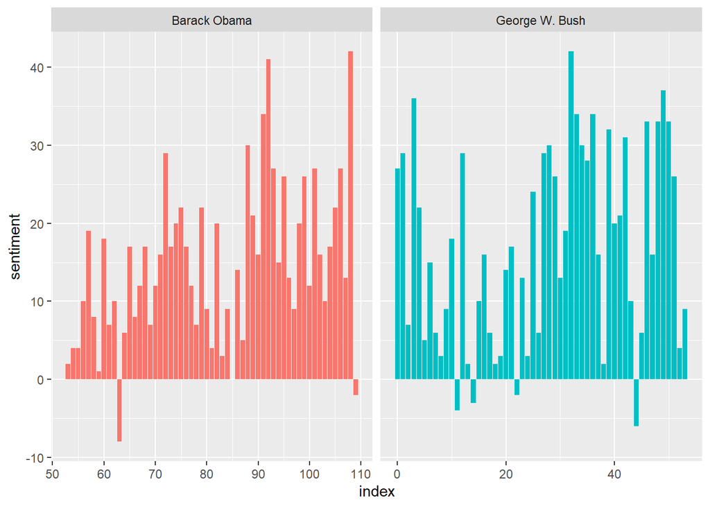

```r
ggplot(union_sentiment, aes(index, sentiment, fill = president)) +
  geom_col(show.legend = FALSE) +
  facet_wrap(~president, ncol = 2, scales = "free_x")
```

```r
bad_sentiments <- get_sentiments("nrc") %>%
  filter(sentiment %in% c("negative"))
```

Some more interesting differences can be seen in the negative terms each president used.

```r
tidy_speech %>%
  filter(party == "Democrats") %>%
  inner_join(bad_sentiments) %>%
  count(word, sort = TRUE)
```

| word | n |
| --- | --- |
| tax | 77 |
| government | 62 |
| deficit | 49 |
| small | 35 |
| war | 28 |
| crisis | 25 |
| debt | 24 |
| vote | 23 |
| recession | 20 |
| serve | 15 |

[output cut: 375 more lines]

```r
tidy_speech %>%
  filter(party == "Republicans") %>%
  inner_join(bad_sentiments) %>%
  count(word, sort = TRUE)
```

| word | n |
| --- | --- |
| government | 92 |
| tax | 76 |
| terror | 55 |
| war | 54 |
| fight | 41 |
| terrorist | 31 |
| income | 28 |
| enemy | 25 |
| retirement | 24 |
| small | 24 |

[output cut: 424 more lines]

```r
library(lexicon)
```

```r
pos_preposition <- data.frame(pos_preposition) %>%
                      rename(word = pos_preposition)
```

Using a different lexicon from the lexicon library, the results it gives us aren’t too useful.

```r
tidy_speech %>%
  filter(party == "Democrats") %>%
  inner_join(pos_preposition) %>%
  count(word, sort = TRUE)
```

| word | n |
| --- | --- |
| to | 1373 |
| of | 1004 |
| a | 841 |
| in | 649 |
| for | 420 |
| on | 287 |
| with | 254 |
| but | 240 |
| as | 185 |
| from | 180 |

[output cut: 55 more lines]

```r
tidy_speech %>%
  filter(party == "Republicans") %>%
  inner_join(pos_preposition) %>%
  count(word, sort = TRUE)
```

| word | n |
| --- | --- |
| to | 1379 |
| of | 1229 |
| in | 851 |
| a | 774 |
| for | 377 |
| on | 256 |
| with | 246 |
| by | 220 |
| from | 155 |
| as | 133 |

[output cut: 58 more lines]

The following lexicons give use more interesting results. The first one uses -1 for negative sentiments and 1 for positive ones. Adapting the original code to work with this is very simple. The next two lexicons were a bit more involved. They have a range of values between -1 and 1. First we add a column that determines if a value is either negative or positive. The code given to us only works if we have a binary condition. However, in the count method, we are able to use the wt command to multiply our counts by the weights given in the lexicon. The results can be seen below.

```r
union_sentiment_huliu <- tidy_speech %>%
  inner_join(hash_sentiment_huliu, b  = c ("word"="x")) %>%
  count(president, index = linenumber %/% 10, y) %>%
  pivot_wider(names_from = y, values_from = n, values_fill = 0,names_prefix   = c("neg","pos")) %>%
  mutate(sentiment = pos1 - `neg-1`)
```

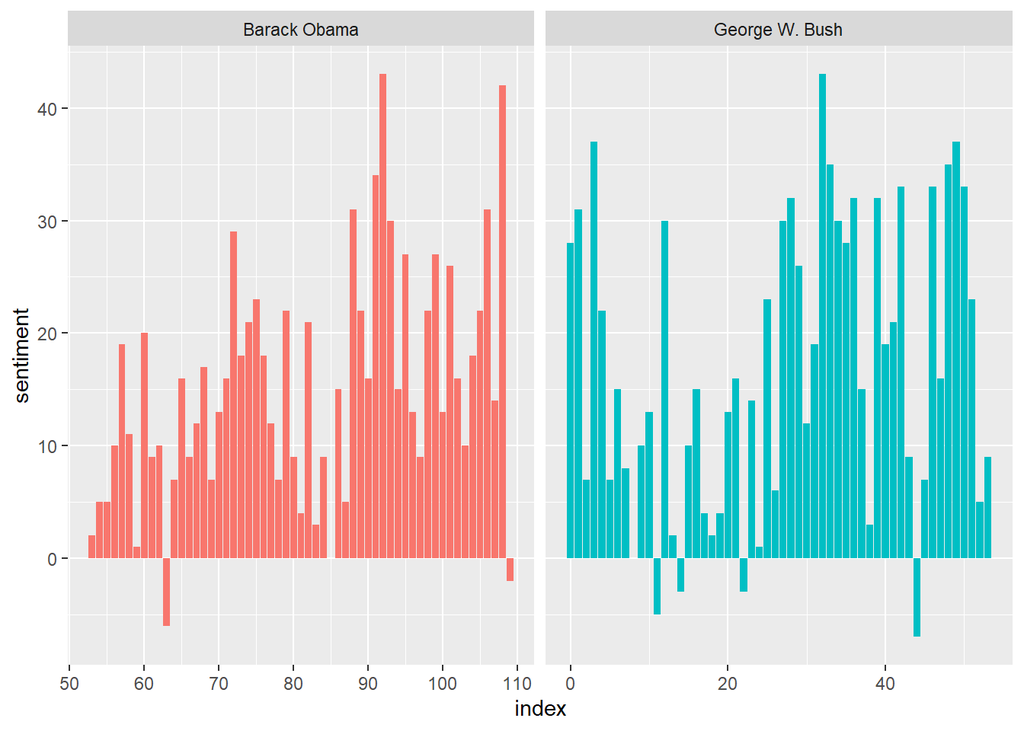

```r
ggplot(union_sentiment_huliu, aes(index, sentiment, fill = president)) +
  geom_col(show.legend = FALSE) +
  facet_wrap(~president, ncol = 2, scales = "free_x")
```

```r
union_sentiment_jockers  <- tidy_speech %>%
  inner_join(hash_sentiment_jockers  , b  = c ("word"="x")) %>%
  mutate(sentiment = if_else(y >0,"pos","neg")) %>%
  count(president, index = linenumber %/% 10, sentiment, wt = abs(y))%>%
  pivot_wider(names_from = sentiment, values_from = n, values_fill = 0) %>%
  mutate(sentiment =   pos-neg )
```

```r
parse_number("saddsa-22")
```

```
## [1] -22
```

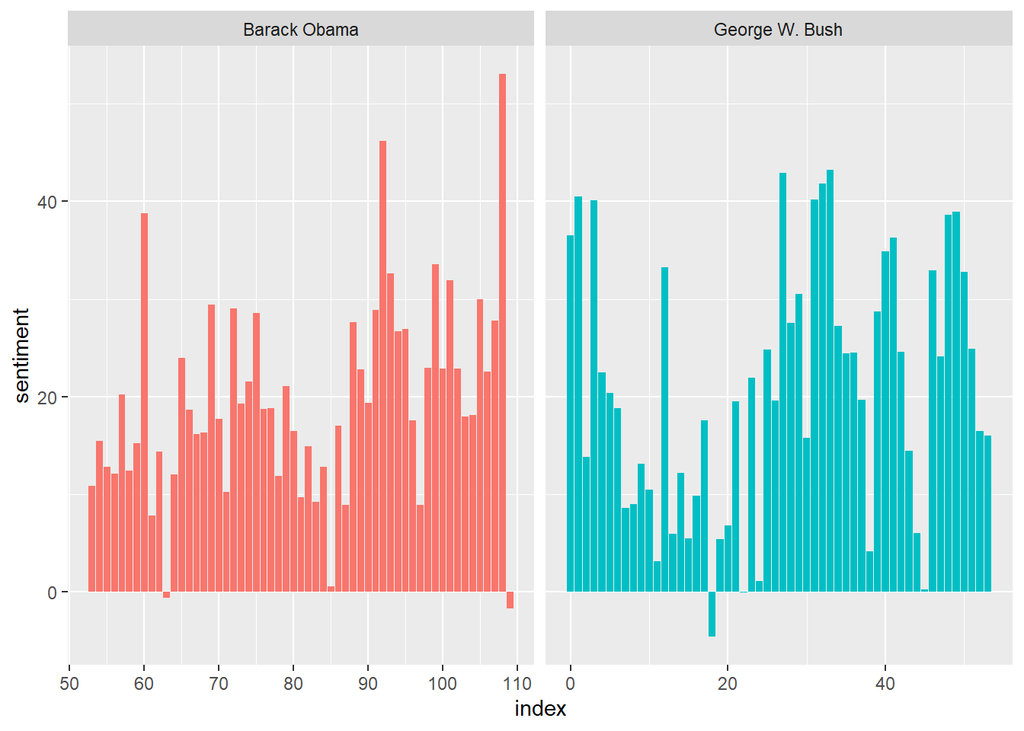

```r
ggplot(union_sentiment_jockers, aes(index, sentiment, fill = president)) +
  geom_col(show.legend = FALSE) +
  facet_wrap(~president, ncol = 2, scales = "free_x")
```

```r
union_sentiment_jockers_rinker  <-
  tidy_speech %>%
  inner_join(hash_sentiment_jockers_rinker  , b  = c ("word"="x")) %>%
   mutate(sentiment = if_else(y >0,"pos","neg")) %>%
  count(president, index = linenumber %/% 10, sentiment, wt = abs(y))%>%
  pivot_wider(names_from = sentiment, values_from = n, values_fill = 0) %>%
  mutate(sentiment =   pos-neg )
```

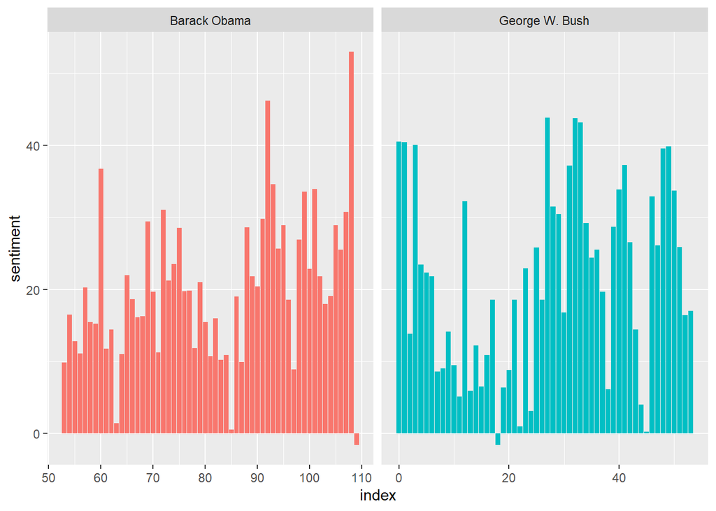

```r
ggplot(union_sentiment_jockers_rinker, aes(index, sentiment, fill = president)) +
  geom_col(show.legend = FALSE) +
  facet_wrap(~president, ncol = 2, scales = "free_x")
```